# TWD3

Wojciech Grabias, Kacper Wnęk

2022-11-22

# Pierwszy zestaw danych reprezentuje wyniki głosowania na ulubioną osobę spośród dwóch (A oraz B). Głosowanie przeprowadzone zostało kolejno na 8 odpowiednio ponumerowanych grupach. Osoba A kojarzyła się powszechnie jednak z kolorem zielonym, zaś osoba B - z połączeniem czerwonego i czarnego, co uwzględnione zostało na wykresie.

# (Badanie 1) Wykres 1 i problemy z nim związane

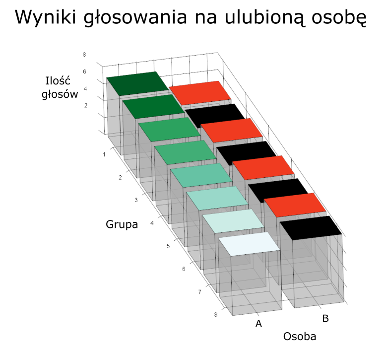

Wykres pierwszy ma na celu wskazanie na problemy z odczytem danych spowodowanych:

1. na skutek powstałej iluzji ze względu na użyte kolory
2. złudzenia stworzonego poprzez perspektywę
3. specyfiki wykresu 3d - trudność w odczytaniu wartości dalekich od osi

# (Badanie 1) Pytania do wykresu i opis badania

Link do ankiety: https://docs.google.com/forms/d/1ZlFIqIlrLQZS65oJ_p_-2mFOAkANl_6F6ZDxfck_3VY/prefill

W celu sprawdzenia nieskuteczności przekazu informacji przez wykres 3D, ankietowany postawiony został przed 5 pytaniami typu Prawda/Fałsz:

1. W każdej kolejnej grupie osoba A uzyskiwała coraz mniej głosów
2. Osoba A otrzymała 6 głosów w grupie 8
3. Osoba A otrzymała tyle samo głosów w grupie 8, co osoba B w grupie 4
4. Osoba B otrzymała tyle samo głosów w 5 i 6 grupie
5. Osoba B wygrała głosowanie w grupach 3-8

z których tylko zdanie nr 4 było poprawne.

Następnie ankietowany był poproszony o odpowiedzenie na te same pytania w oparciu o wykres “prawidłowy” (2D, bez zbędnie przesadzonej kolorystyki i pozbawiony złudzeń optycznych):

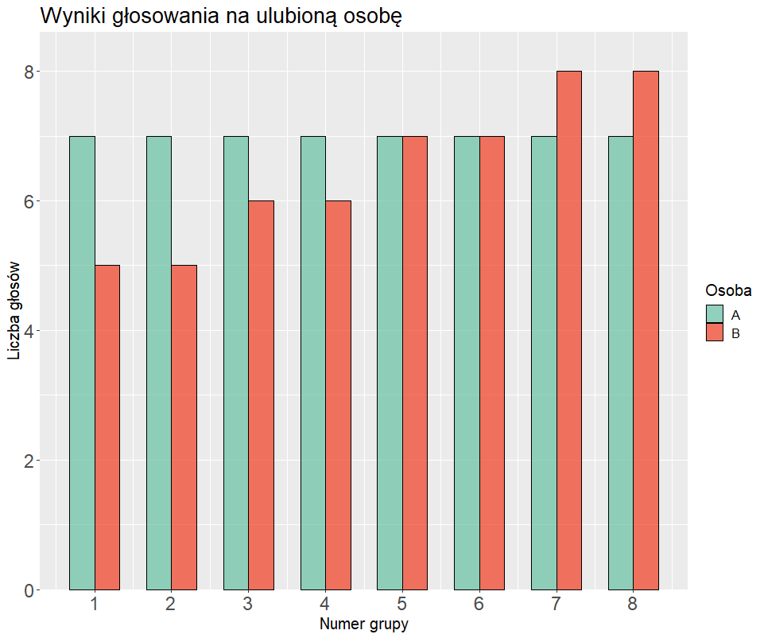

Ostatecznie ankietowany został zapytany o to, czy wykresy te przedstawiały inne dane oraz o skalę porównawczą łatwości odczytywania danych z dwóch powyższych wykresów.

# (Badanie 1) Wyniki badania i wnioski cz.1

Pamiętając, że jedynie zdanie numer 4 jest zdaniem poprawną, wynik 16 ankietowanych może być zdumiewający:

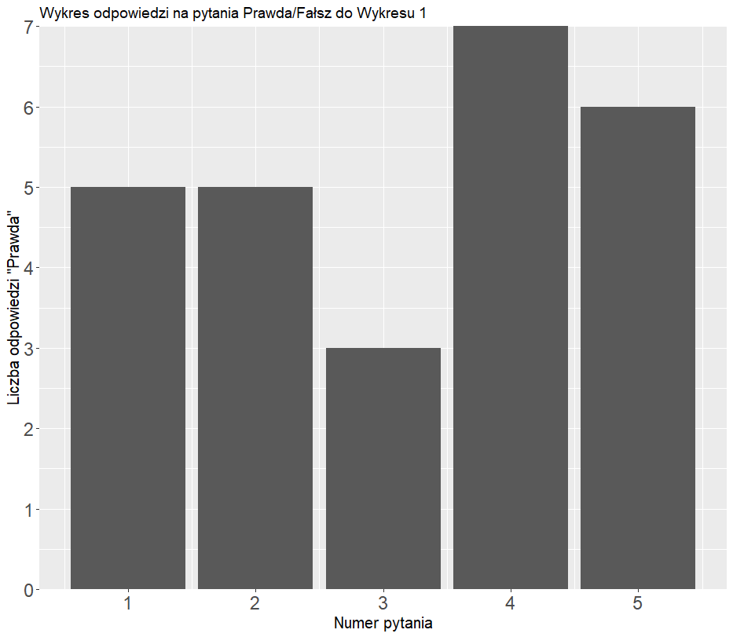

Zaledwie 7 ankietowanym osobom udało się poprawnie odpowiedzieć na to pytanie. Świadczy to o tym, że złudzenie optyczne wynikające z naprzemiennego użycia koloru jaskrawego (w tym wypadku czerwonego) oraz czarnego zminenia postrzeganie wysokości słupków.

Specyfika wykresu 3D okazała się najmniej podchwytliwa - niemniej jednak 3 osoby źle porównały wysokości słupków w przestrzeni.

Na koniec warto dodać, że jedynie 3 ze wszystkich ankietowanych uzyskałyby komplet punktów za to zadanie.

Porównajmy odpowiedzi na te pytania na bazie wykresu 2:

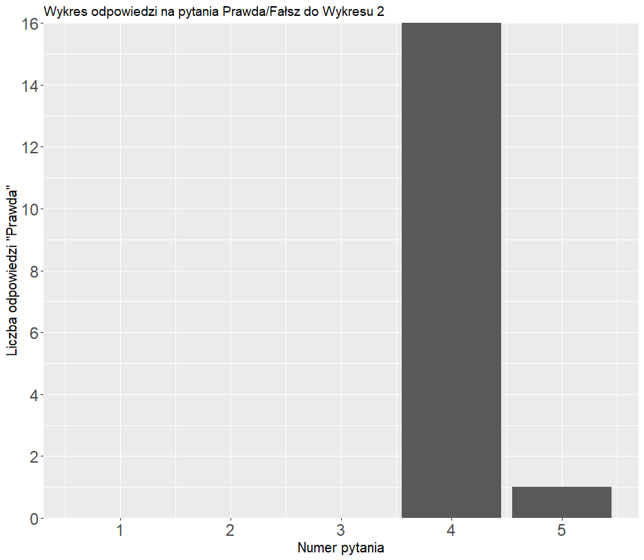

Potwierdza to tezę, że to nie ze względu na specyfikę danych, a sposób ich przedstawienia, wśród ankietowanych pojawiły się problemy z poprawnym odczytem danych. Jak widać na przedstawionym wyżej wykresie, wszystkie osoby poprawnie zaznaczyły odpowiedź przy zdaniu nr 4, z kolei tylko jedna osoba - być może omyłkowo - pomyliła się przy zdaniu nr 5.

# (Badanie 1) Wyniki badania i wnioski cz.2

Pytanie odnoszące się do tego, czy wykresy przedstawiają wizualizację tego samego zestawu danych również dostarcza interesujących wniosków:

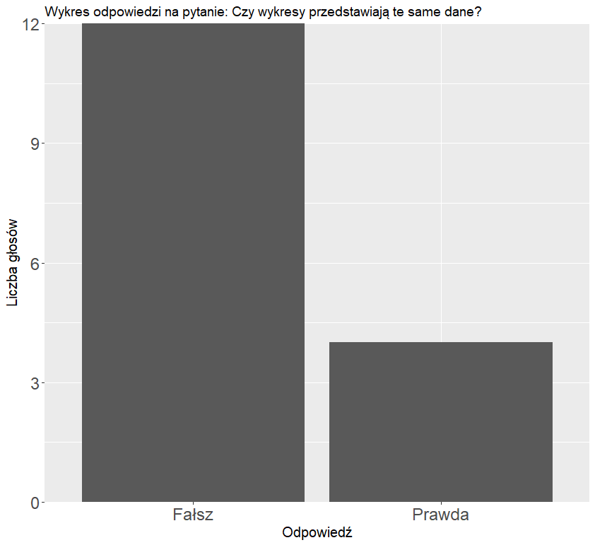

Co więcej, każdy z ankietowanych poproszony był o określenie, w jakim stopniu (w skali od 1-10) łatwiejsze w odczycie były dane z wykresu 2D. W tym przypadku również wyniki badania mówią same za siebie:

| Odpowiedz | Liczba.Odpowiedzi |
| --- | --- |
| 1 | 0 |
| 2 | 0 |
| 3 | 0 |
| 4 | 0 |
| 5 | 0 |
| 6 | 0 |
| 7 | 0 |
| 8 | 0 |
| 9 | 1 |
| 10 | 15 |

Niemal każdy z ankietowanych uznał, że bezkonkurencyjnie lepszą opcją jest wykres słupkowy 2D, ostatecznie rozwiewając wszelkie argumenty za zastosowaniem wykresu 3D

Podsumowując, eksperyment dowiódł tezy, że wykresy 3D z niepoprawnie dobraną kolorystyką zaburzają percepcję danych umieszczonych na wykresach. Potwierdzają to zarówno bezpośrednie wyniki ankietowanych, jak i ich osobiste odczucia. Ilość poprawnych odpowiedzi w przypadku wykresu 2D utwierdza w przekonaniu, że to właśnie sposób przedstawienia danych jest winny niepoprawnemu odbiorowi danych.

# Omówienie zestawu danych danych numer 2

Drugi zestaw danych przedstawia wyniki ankiety odnośnie ulubionych klubów piłkarskich pewnej 50-osobowej grupy.

# (Badanie 2) Wykres 1 i problemy z nim związane

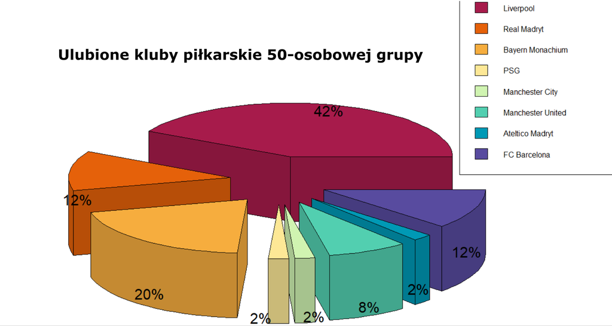

Wykres nr 1 przedstawia pewne dane za pomocą diagramu kołowego 3D. Taka postać diagramu powoduje, że dane analizuje się zdecydowanie wolniej, a nawet łatwiej jeśli chodzi o pomyłki. Największym problemem okazuje się oparcie wykresu na kolorystycznym rozróżnieniu poszczególnych jego części, przez co w przypadku kolorów zbliżonych do siebie odbiorcy mają trudności w analizie wykresu, ten problem jest szczególnie uciążliwy, a w zasadzie nie do pokonania dla osób z wadami wzrokowymi np. daltonizmem.

# (Badanie 2) Pytania do wykresu i opis badania

Ankietowani zostali poproszeni, aby na podstawie wykresu odpowiedzieć, która ze wskazanych drużyn ma więcej kibiców, a następnie o przypisanie klubom odpowiednich miejsc adekwatnych do liczby posiadanych kibiców. Na podstawie tego zadania ankietowani sami ocenią łatwość odczytu danych z wykresu. Przeanalizowane zostaną również potencjalne błędy odczytu danych.

Ponadto, analogicznie do Badania 1, ankietowani poproszeni zostaną o ocenę łatwośći odczytu danych oraz w tym przypadku również - o czas potrzebny do uzyskania informacji.

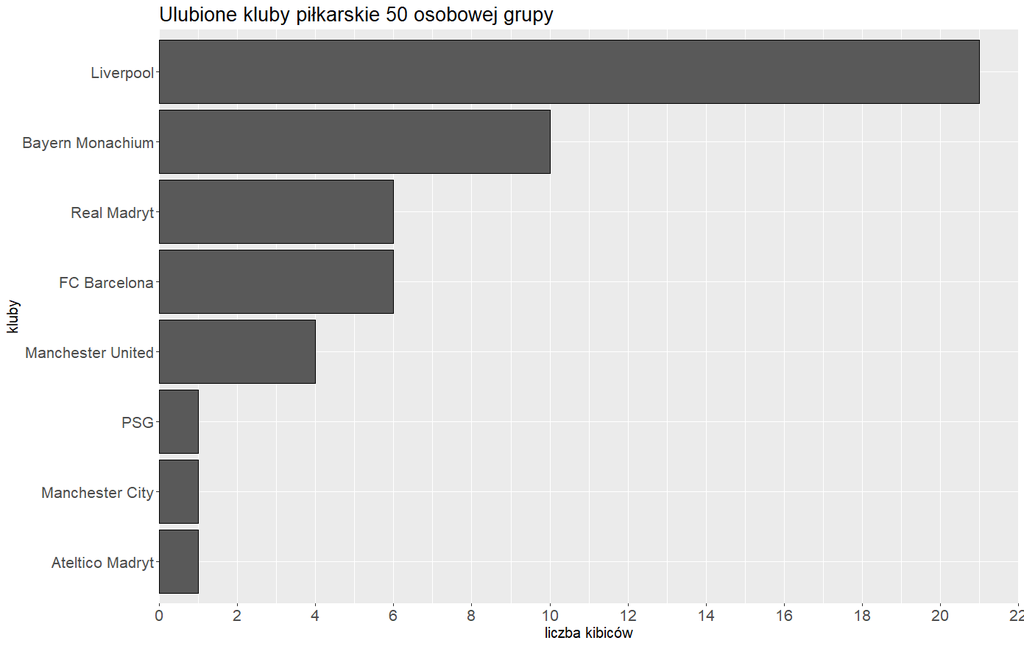

Wykres nr 2 przedstawia te same dane, co poprzedni wykres jednak za pomocą diagramu słupkowego. Taki rodzaj diagramu jest przez odbiorców znacznie szybciej analizowany, a także w analizie jego dokonują oni mniejszej ilości pomyłek. Nie występuje tutaj problem z rozpoznawaniem kolorów, ponieważ wykres jest opisany w sposób przejrzysty i nie oparty na różnicy barw

# (Badanie 2) Wyniki badania i wnioski cz. 1

Poniższe wykresy przedstawiają liczbę popełnionych błędów w porządkowaniu drużyn przez ankietowanych:

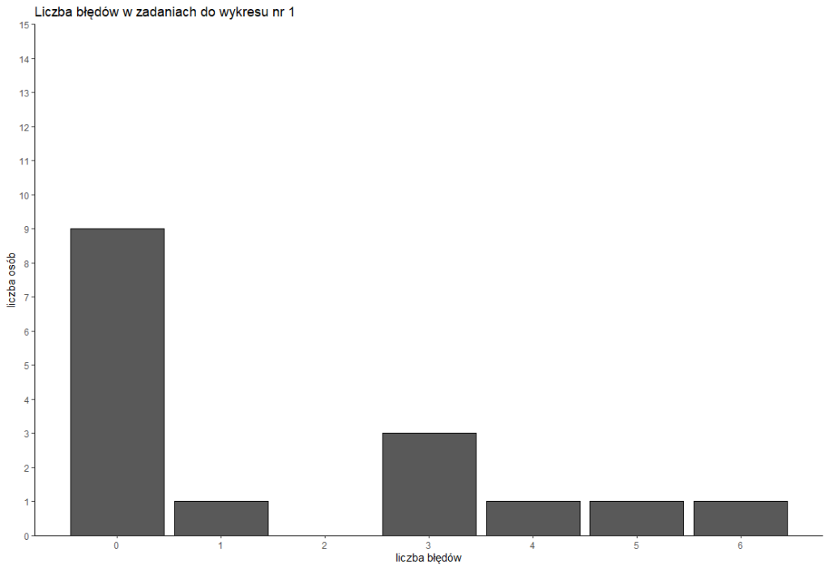

Na wykresie możemy zobaczyć, że większości udało się poprawnie odpowiedzieć na pytania, 9 osób odpowiedziało bezbłędnie. Oznacza, to że aż 7 osób popełniło błędy w zadaniach. Jak możemy zauważyć zdarzały się rozwiązania nawet z 5/6 błędami. Zdecydowana większość popełnionych błędów była spowodowana podobieństwem kolorów między dwoma częściami wykresu, co pokazuje, że wykresy oparte na kolorystycznym rozróżnieniu poszczególnych jego części się nie sprawdzają.

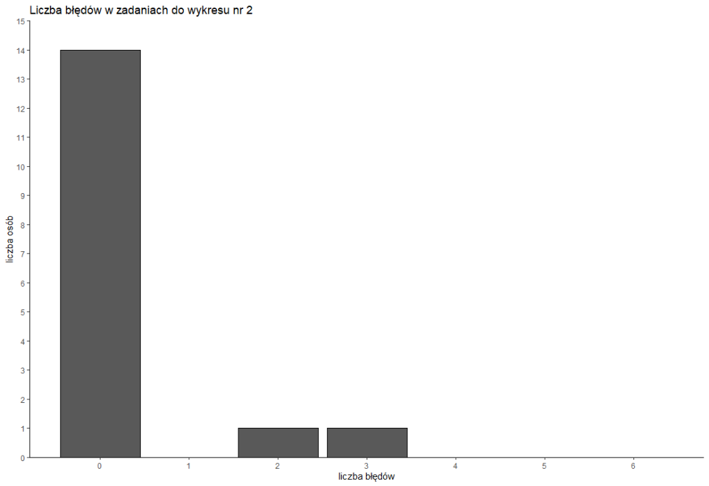

Analogiczne zadania do wykresu nr 2 w sposób bezbłędny rozwiązało aż 14 osób, jest to znaczna poprawa względem wyników z zadań do wykresu nr 1. Dwie prace z błędami miały odpowiednio 2 i 3 błędy. Mała liczba błędów potwierdza, że społeczeństwo ma problemy z analizą danych z wykresów 3D/wykresów kołowych.

# (Badanie 2) Wyniki badania i wnioski cz. 2

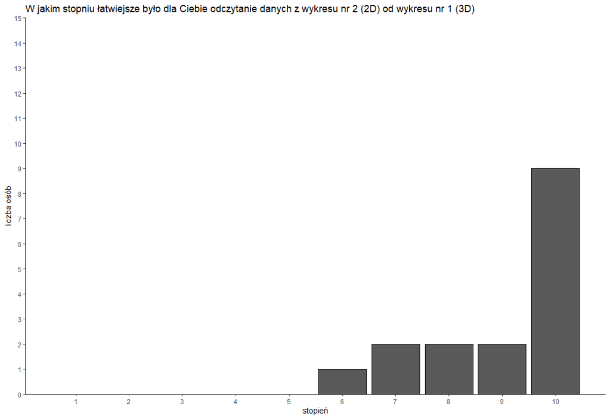

Z wykresu możemy łatwo odczytać jaka jest opinia ankietowanych na temat obu wykresów. Opinia ankietowanych potwierdza przypuszczenie, że wykres 2D jest bardziej przejrzysty w kontekście odczytu danych. Ze wszystkich ankietowanych nawet jedna osoba nie opowiedziała się za wykresem nr 1 jeśli chodzi o poziom trudności w analizie (wszystkie odpowiedzi należą do przedziału [6,10] z wielką przewagą 10).

Wyniki odpowiedzi na pytanie odnoszące się do tego, który z wykresów umożliwia szybszy odczyt danych z wykresu są jednogłośne:

| Numer.ankiety | Odpowiedz |
| --- | --- |
| 1 | Wykres 2 |
| 2 | Wykres 2 |
| 3 | Wykres 2 |
| 4 | Wykres 2 |
| 5 | Wykres 2 |
| 6 | Wykres 2 |
| 7 | Wykres 2 |
| 8 | Wykres 2 |
| 9 | Wykres 2 |
| 10 | Wykres 2 |
| 11 | Wykres 2 |
| 12 | Wykres 2 |
| 13 | Wykres 2 |
| 14 | Wykres 2 |
| 15 | Wykres 2 |
| 16 | Wykres 2 |

Fakt, że ani jedna osoba nie oddała głosu na wykres nr 1 potwierdza tezę, że wykresy 3D utrudniają nie tylko poprawność odczytu danych (co potwierdza cz.1 analizy), ale również czas potrzebny na odczyt danych.